# Demo of latent Tree Aggregation Surrogate Variable Analysis

Christophe Ambroise

24/11/2017

# Data Simulation

To simulate Gaussian data with given covariance structure and missing variables:

- chose a graph type (erdös, tree, star)
- deduce a covariance matrix via the construction of a GGM.model object
- draw a random sample from the GGM.model object via the `randomSample()` method

```r
erdos.graph <- graphModel$new(type = "erdos",size=30, p.or.m = 0.2)
```

```
## [1] "Erdös-Renyi graph built"
```

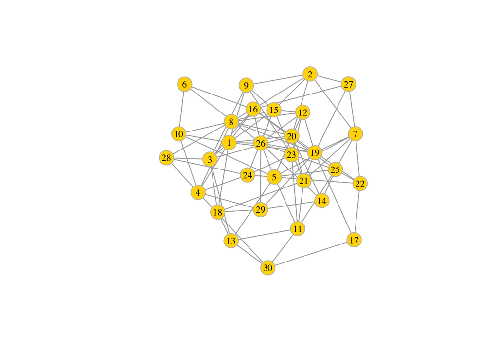

```r
plot(erdos.graph,edge.arrow.size=0, vertex.color="gold",
     vertex.size=15, vertex.frame.color="gray",
     vertex.label.color="black",
     vertex.label.cex=0.8,
     vertex.label.dist=0)
```

```r
star.graph <- graphModel$new(type = "starerdos",size=30, p.or.m = 0.05)
```

```
## [1] "Starred Erdös-Renyi graph built"
```

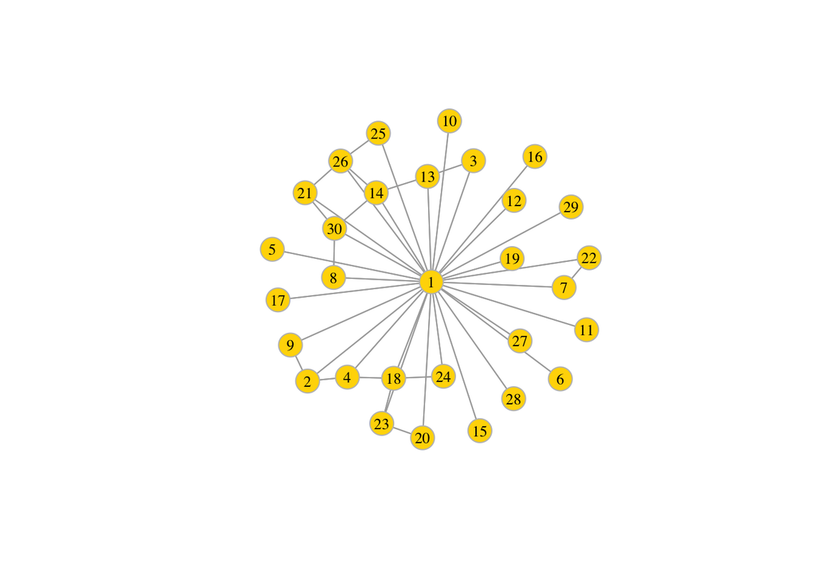

```r
plot(star.graph,edge.arrow.size=0, vertex.color="gold",
     vertex.size=15, vertex.frame.color="gray",
     vertex.label.color="black",
     vertex.label.cex=0.8,
     vertex.label.dist=0)
```

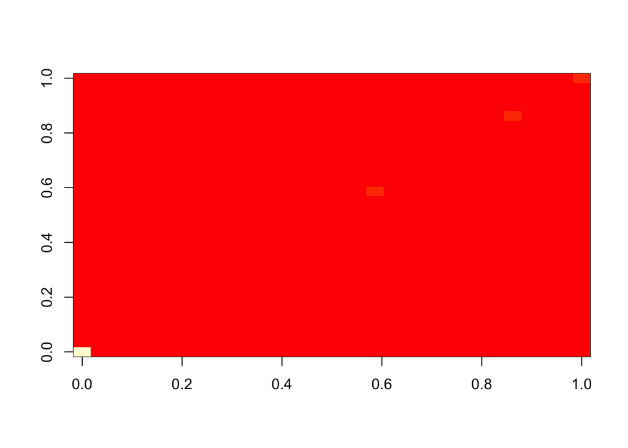

```r
star.model <- GGMmodel$new(graph=star.graph)
plot(star.model)
```

```r
star.model$randomSample(n=50)  # create a random sample asscesible as public variable X in the star.model
```

# Graph inference

To infer the graphical model the class GGM.fit uses a simple data table (assumed to be scaled). If the ground truth is know (for example when simulated data is available), precision recall and roc curve can be computed using the GGM.evaluation class.

## Testing Glasso with no missing variable

```r
star.model.fit <-GGMfit$new(star.model$getX(),method="glasso")
str(star.model.fit)
```

```
## Classes 'GGMfit', 'R6' <GGMfit>
##   Public:
##     clone: function (deep = FALSE)
##     fit.number: 20
##     initialize: function (X, method = "glasso", nb.missing.var = 0, fit.number = 20,
##     K.score: NULL
##     method: glasso
##     nb.missing.var: 0
##     run: function (bagging = FALSE, nb.bootstrap = 29)
##     runBagging: function (nb.bootstrap)
##     X: -0.266942250781929 -0.0683080242965689 -0.22136924481794 ...
##   Private:
##     runSimple: function (X)
```

```r
testingGlasso<-GGMexperiment$new(X.list = list(star.model$getX()), adjmat = star.model$getAdjmat())
testingGlasso$run()
print(glasso.auc<-testingGlasso$auc())
```

```
##              auc method
## glasso 0.8682574 glasso
```

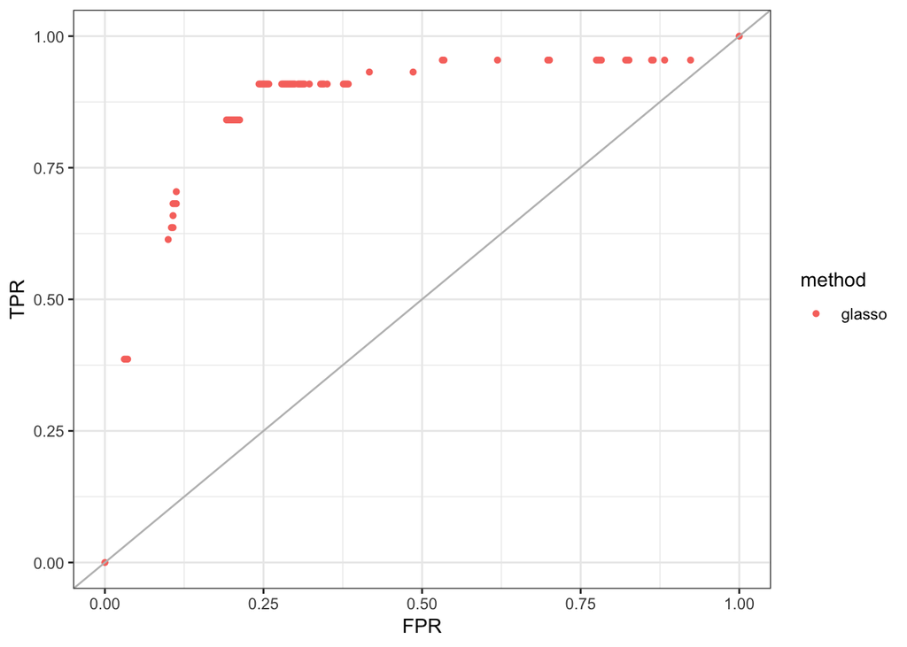

```r
testingGlasso$roc.plot()
```

## Comparing Chow-Liu and Glasso with no missing variable

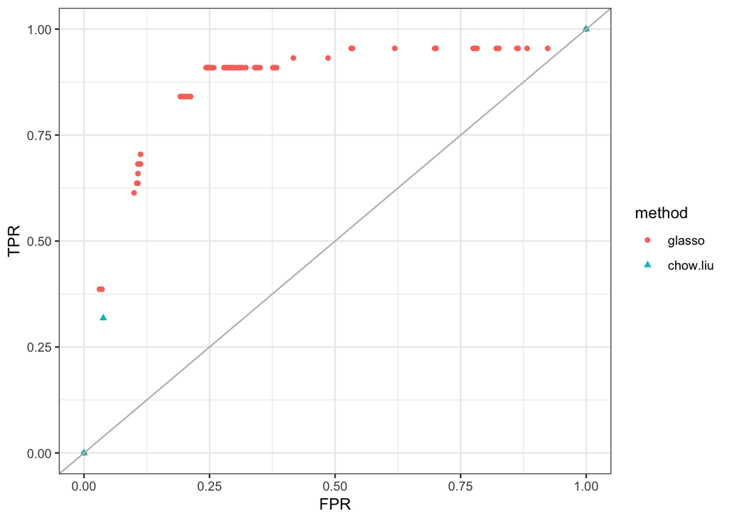

```r
testingGlasso<-GGMexperiment$new(X.list = list(star.model$getX()), adjmat = star.model$getAdjmat(),methods=c("glasso","chow.liu"))
testingGlasso$run()
testingGlasso$roc.plot()
```

```r
print(auc<-testingGlasso$auc())
```

```
##                auc   method
## glasso   0.8682574   glasso
## chow.liu 0.6399093 chow.liu
```

## Comparing Chow-Liu and Glasso with no missing variable using 10 samples of size 30

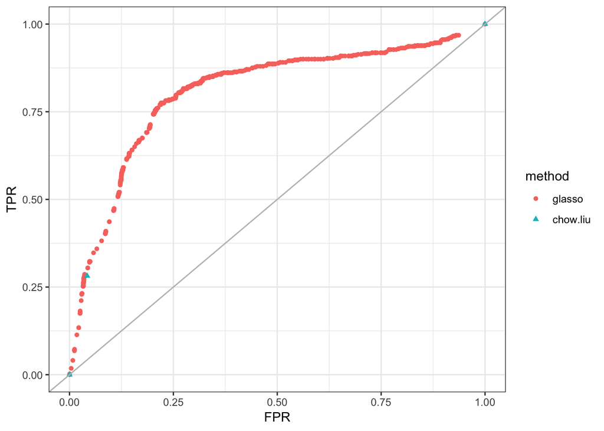

```r
X.list<- lapply(vector(mode = "list", length = 10), function(x) {star.model$randomSample(30)
                                                                 star.model$getX()  } )
testingGlasso<-GGMexperiment$new(X.list = X.list, adjmat = star.model$getAdjmat(),methods=c("glasso","chow.liu"))
testingGlasso$run()
testingGlasso$roc.plot()
```

```r
print(auc<-testingGlasso$auc())
```

```
##                auc   method
## glasso   0.8053588   glasso
## chow.liu 0.6196815 chow.liu
```

## Comparing Chow-Liu and Glasso with no missing variable using bagging

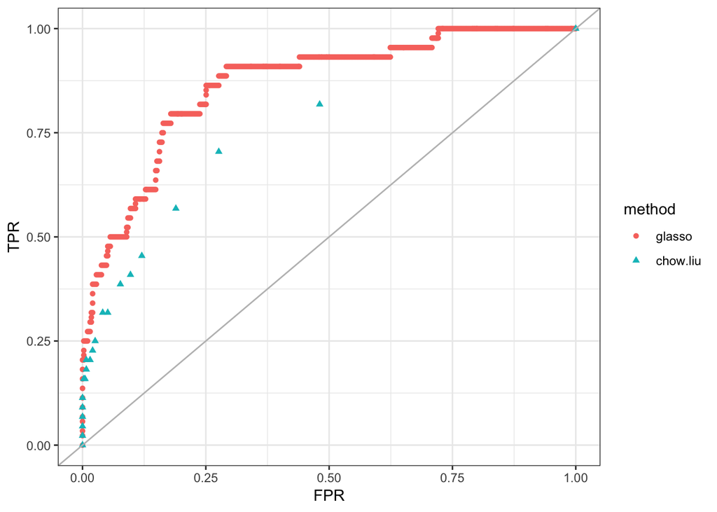

```r
testingGlasso<-GGMexperiment$new(X.list = list(star.model$getX()), adjmat = star.model$getAdjmat(),methods=c("glasso","chow.liu"))
testingGlasso$run(bagging=TRUE)
testingGlasso$roc.plot()
```

```r
print(auc<-testingGlasso$auc())
```

```
##                auc   method
## glasso   0.8656708   glasso
## chow.liu 0.7581958 chow.liu
```

# Introduction missing variable

The GGM.model class allows to specify a number of missing variables, which are chosen among the nodes of highest degree. If there are some missing variable two matrices of adjacency are available:

- the full adjacency matrix
- the conditional adjacency matrix (relative to the observed variables)

And after the simulation of a random sample to data matrices are available:

- The full data matrix $X$, with observed and latent variables
- The observed data matrix $X_{obs}$

When the model is fitted with observed data, two evaluation can be performed, if the algorithm takes into account missing data

- the evaluation on the conditional graph,
- the evaluation on the full graph.

# Testing Glasso with one missing variable

```r
star.model.missing <- GGMmodel$new(graph=star.graph,nb.missing.var= 1)
dim(star.model.missing$getAdjmat())
```

```
## [1] 30 30
```

```r
dim(star.model.missing$getAdjmatCond())
```

```
## [1] 29 29
```

```r
star.model.missing$randomSample(n=60)
dim(star.model.missing$getX())
```

```
## [1] 60 30
```

```r
dim(star.model.missing$getXobs())
```

```
## [1] 60 29
```

```r
star.model.missing.fit <-GGMfit$new(star.model.missing$getXobs(),fit.number = 20,method="glasso")
star.model.missing.fit$run()
star.model.missing.fit2 <-GGMfit$new(star.model.missing$getXobs(),nb.missing.var= 1,fit.number = 20,method="em.latent.trees")
star.model.missing.fit2$run()
```

[output not shown]